# Day 3 code

## 3.1 Unconditional growth

We can start the modeling from the unconditional growth model. In this specification, `exper` plays the role of **TIME** indicator.

```r
mlm.1 <- lme(fixed = lnw ~ 1 + exper,
             random = ~ 1 + exper | id,
             data = df_wages,
             method = "REML")
summary(mlm.1)
```

```
Linear mixed-effects model fit by REML
  Data: df_wages
       AIC      BIC    logLik
  4951.272 4991.856 -2469.636

Random effects:
 Formula: ~1 + exper | id
 Structure: General positive-definite, Log-Cholesky parametrization
            StdDev    Corr
(Intercept) 0.2332252 (Intr)
exper       0.0416237 -0.302
Residual    0.3083835

Fixed effects:  lnw ~ 1 + exper
                Value   Std.Error   DF   t-value p-value
(Intercept) 1.7156090 0.010803682 5513 158.79855       0
exper       0.0456804 0.002343769 5513  19.49014       0
 Correlation:
      (Intr)
exper -0.565

Standardized Within-Group Residuals:
        Min          Q1         Med          Q3         Max
-4.20138076 -0.52101490 -0.03145136  0.44043473  7.03695068

Number of Observations: 6402
Number of Groups: 888
```

Compared to the previous example, though, we now have an individual-level, time-invariant predictor: a person’s racial background. For racial background it’s relatively easy, but if we had another variable, how could we tell at which lever it is measured on? Well, there are many ways to do this, but a simple one is to check whether within an individual there is any variation in the variable, over time. If there isn’t, it’s a good bet that the variable is time invariant.

```r
df_wages %>%
    group_by(id) %>%
    summarise(black_sd = sd(black, na.rm = TRUE)) %>%
    slice(1:20) %>%
    kable(digits = 3,
          col.names = c("ID", "SD(black)"),
          caption = "SD of racial background for 20 individuals",
          caption.above = TRUE)
```

SD of racial background for 20 individuals

| ID | SD(black) |
| --- | --- |
| 31 | 0 |
| 36 | 0 |
| 53 | 0 |
| 122 | 0 |
| 134 | 0 |
| 145 | 0 |
| 155 | 0 |
| 173 | 0 |
| 206 | 0 |
| 207 | 0 |
| 222 | 0 |
| 223 | 0 |
| 226 | 0 |
| 234 | 0 |
| 241 | 0 |
| 248 | 0 |
| 253 | 0 |
| 266 | NA |
| 295 | 0 |
| 299 | 0 |

**Question**: What is another way in which you can check if a variable truly is measured at the L2 or not?

Because of the way it is included in the model, our specification posits that racial background is a predictor for the random intercept.

```r
df_wages <- df_wages %>%
    mutate(black = as.character(black))

mlm.2 <- lme(fixed = lnw ~ 1 + exper + black,
             random = ~ 1 + exper | id,
             data = df_wages,
             method = "REML")
summary(mlm.2)
```

```
Linear mixed-effects model fit by REML
  Data: df_wages
       AIC      BIC    logLik
  4957.449 5004.796 -2471.724

Random effects:
 Formula: ~1 + exper | id
 Structure: General positive-definite, Log-Cholesky parametrization
            StdDev     Corr
(Intercept) 0.23409806 (Intr)
exper       0.04160816 -0.31
Residual    0.30838322

Fixed effects:  lnw ~ 1 + exper + black
                 Value   Std.Error   DF   t-value p-value
(Intercept)  1.7232534 0.012226746 5513 140.94130  0.0000
exper        0.0455879 0.002343975 5513  19.44896  0.0000
black1      -0.0270726 0.020026737  886  -1.35183  0.1768
 Correlation:
       (Intr) exper
exper  -0.519
black1 -0.465  0.036

Standardized Within-Group Residuals:
        Min          Q1         Med          Q3         Max
-4.20674272 -0.51703771 -0.03222294  0.43785047  7.03321303

Number of Observations: 6402
Number of Groups: 888
```

```r
anova(mlm.1, mlm.2)
```

```
      Model df      AIC      BIC    logLik   Test  L.Ratio p-value
mlm.1     1  6 4951.272 4991.856 -2469.636
mlm.2     2  7 4957.449 5004.796 -2471.724 1 vs 2 4.177116   0.041
```

Uh-oh. Unfortunately, for output objects produced by the `lme()` function, `anova()` doesn’t re-estimate them automatically with **FIML**, so we have to do it.

```r
mlm.1.fiml <- update(mlm.1, method = "ML")
mlm.2.fiml <- update(mlm.2, method = "ML")

anova(mlm.1.fiml, mlm.2.fiml)
```

```
           Model df      AIC      BIC    logLik   Test  L.Ratio p-value
mlm.1.fiml     1  6 4933.394 4973.980 -2460.697
mlm.2.fiml     2  7 4933.584 4980.935 -2459.792 1 vs 2 1.810058  0.1785
```

```r
rm(mlm.1.fiml)
```

## 3.2 Expanding model

```r
mlm.3 <- lme(fixed = lnw ~ 1 + exper + black + black * exper,
             random = ~ 1 + exper | id,
             data = df_wages,
             method = "ML")
summary(mlm.3)
```

```
Linear mixed-effects model fit by maximum likelihood
  Data: df_wages
       AIC      BIC    logLik
  4925.064 4979.179 -2454.532

Random effects:
 Formula: ~1 + exper | id
 Structure: General positive-definite, Log-Cholesky parametrization
            StdDev     Corr
(Intercept) 0.23294190 (Intr)
exper       0.04080522 -0.302
Residual    0.30841876

Fixed effects:  lnw ~ 1 + exper + black + black * exper
                  Value   Std.Error   DF   t-value p-value
(Intercept)   1.7120996 0.012671608 5512 135.11305  0.0000
exper         0.0497042 0.002644974 5512  18.79193  0.0000
black1        0.0173503 0.024235999  886   0.71589  0.4742
exper:black1 -0.0179923 0.005527623 5512  -3.25497  0.0011
 Correlation:
             (Intr) exper  black1
exper        -0.567
black1       -0.523  0.296
exper:black1  0.271 -0.479 -0.565

Standardized Within-Group Residuals:
        Min          Q1         Med          Q3         Max
-4.19901731 -0.52432461 -0.03179397  0.44433308  7.03650498

Number of Observations: 6402
Number of Groups: 888
```

```r
mlm.3.fiml <- update(mlm.3, method = "ML")
anova(mlm.2.fiml, mlm.3.fiml)
```

```
           Model df      AIC      BIC    logLik   Test  L.Ratio p-value
mlm.2.fiml     1  7 4933.584 4980.935 -2459.792
mlm.3.fiml     2  8 4925.064 4979.179 -2454.532 1 vs 2 10.52017  0.0012
```

```r
rm(mlm.2.fiml)
```

This last specification looks a lot like types of models that we tried in the last week in course. How would you interpret, in the context of a longitudinal model:

1. the effect of `exper`?
2. the effect of `black`?
3. the effect of the cross-level interaction?

## 3.3 Presenting results

Though we could, of course, present a nicely-formatted table of results from this specification, it’s far more helpful for an audience to visualize the effects we’re talking about. This is where the `ggpredict()` function can help us out, since we can plot trajectories of change and effects for specific sub-groups in the sample.

Plotting the predicted trajectories of a typical Black and non-Black person after entering the job market. Remember our discussion from yesterday, about sources of uncertainty when designing plots of predicted values. This function visibly only incorporates the sampling uncertainty that comes from the fixed effects.

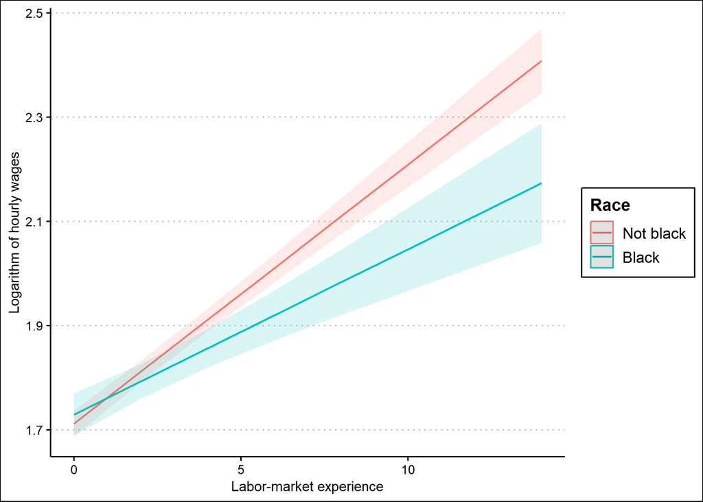

```r
dat1 <- ggpredict(mlm.3,
                  terms = c("exper", "black [0, 1]"),
                  ci.lvl = 0.95,
                  type = "fe")

plot(dat1,
     show.title = FALSE,
     show.x.title = FALSE,
     show.y.title = FALSE) +
  scale_color_discrete(name = "Race",
                       breaks = c("0","1"),
                       labels = c("Not black","Black")) +
  scale_x_continuous(name = "Labor-market experience") +
  scale_y_continuous(name = "Logarithm of hourly wages") +
  theme_clean()
```

```r
rm(dat1)
```

You can also switch the logic around, and plot how African-Americans and their peers are doing in terms of hourly wages at different levels of labor market experience.

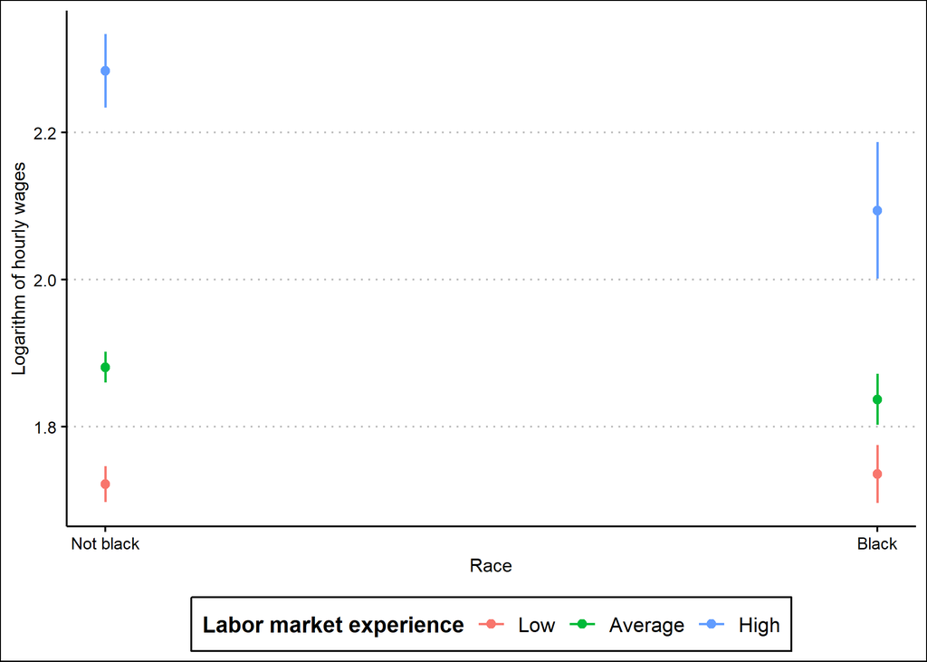

```r
dat2 <- ggpredict(mlm.3,
                  terms = c("black", "exper [0.2, 3.4, 11.5]"),
                  ci.lvl = 0.95,
                  type = "fe")

plot(dat2,
     show.title = FALSE,
     show.x.title = FALSE,
     show.y.title = FALSE,
     dodge = NULL,
     ci.style = "errorbar") +
  scale_color_discrete(name = "Labor market experience",
                       breaks = c(0.2,3.4,11.5),
                       labels = c("Low","Average","High")) +
  scale_x_continuous(name = "Race",
                     breaks = c(0,1),
                     labels = c("Not black","Black")) +
  scale_y_continuous(name = "Logarithm of hourly wages") +
  theme_clean() +
  theme(legend.position = "bottom")
```

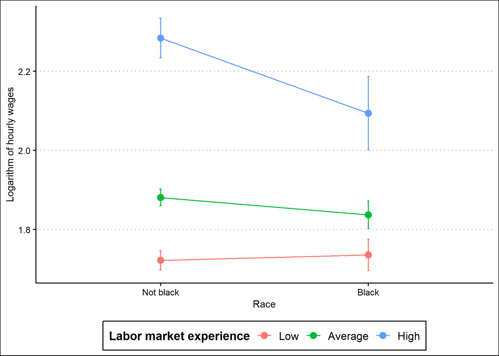

```r
ggplot(dat2,
       aes(x = x,
           y = predicted,
           color = group,
           group = group)) +
  geom_point(size = 3) +
  geom_line() +
  geom_errorbar(aes(ymin = conf.low,
                    ymax = conf.high,
                    color = group),
                width = 0.01) +
  theme_clean() +
  scale_color_discrete(name = "Labor market experience",
                       breaks = c(0.2,3.4,11.5),
                       labels = c("Low","Average","High")) +
  scale_x_discrete(name = "Race",
                   breaks = c("0","1"),
                   labels = c("Not black","Black")) +
  scale_y_continuous(name = "Logarithm of hourly wages") +
  theme(legend.position = "bottom")
```

## 3.4 Expanding model again

We can improve on the specification above by adding another factor: unemployment in the local geographic area, centered around the value of 7%.

```r
mlm.4 <- lme(fixed = lnw ~ 1 + exper + black + black * exper +
                 ue.7,
             random = ~ 1 + exper | id,
             data = df_wages,
             method = "ML")
summary(mlm.4)
```

```
Linear mixed-effects model fit by maximum likelihood
  Data: df_wages
       AIC      BIC    logLik
  4887.161 4948.041 -2434.581

Random effects:
 Formula: ~1 + exper | id
 Structure: General positive-definite, Log-Cholesky parametrization
            StdDev     Corr
(Intercept) 0.23102821 (Intr)
exper       0.04064583 -0.309
Residual    0.30777841

Fixed effects:  lnw ~ 1 + exper + black + black * exper + ue.7
                  Value   Std.Error   DF   t-value p-value
(Intercept)   1.7417036 0.013449284 5511 129.50158  0.0000
exper         0.0447021 0.002753346 5511  16.23556  0.0000
black1        0.0047795 0.024188175  886   0.19760  0.8434
ue.7         -0.0114469 0.001808165 5511  -6.33068  0.0000
exper:black1 -0.0183017 0.005508369 5511  -3.32253  0.0009
 Correlation:
             (Intr) exper  black1 ue.7
exper        -0.613
black1       -0.517  0.309
ue.7         -0.349  0.289  0.082
exper:black1  0.253 -0.456 -0.566  0.009

Standardized Within-Group Residuals:
        Min          Q1         Med          Q3         Max
-4.25655640 -0.52266537 -0.03439262  0.44191766  6.99873843

Number of Observations: 6402
Number of Groups: 888
```